# Peer-graded Assignment: Prediction Assignment Writeup

Stefano Vedovelli (spinwing) spinwing at yahoo dot it

# Peer-graded Assignment: Prediction Assignment Writeup

## Synopsis

Using devices such as Jawbone Up, Nike FuelBand, and Fitbit it is now possible to collect a large amount of data about personal activity relatively inexpensively. These type of devices are part of the quantified self movement - a group of enthusiasts who take measurements about themselves regularly to improve their health, to find patterns in their behavior, or because they are tech geeks. One thing that people regularly do is quantify how much of a particular activity they do, but they rarely quantify how well they do it.

In this project, we will use data from accelerometers on the belt, forearm, arm, and dumbell of 6 participants. They were asked to perform barbell lifts correctly and incorrectly in 5 different ways.

We will use those data to identify via Machine Learning if the subjects will perform correctly 10 repetitions of the Unilateral Dumbbell Biceps Curl.

## Credits

Data was acquired from http://web.archive.org/web/20161224072740/http:/groupware.les.inf.puc-rio.br/har. Training and testing sets were already provided as: https://d396qusza40orc.cloudfront.net/predmachlearn/pml-training.csv https://d396qusza40orc.cloudfront.net/predmachlearn/pml-testing.csv

Velloso, E.; Bulling, A.; Gellersen, H.; Ugulino, W.; Fuks, H. Qualitative Activity Recognition of Weight Lifting Exercises. Proceedings of 4th International Conference in Cooperation with SIGCHI (Augmented Human ’13) . Stuttgart, Germany: ACM SIGCHI, 2013.

Read more: http://web.archive.org/web/20161224072740/http:/groupware.les.inf.puc-rio.br/har#ixzz4qa54zvAC

## Notes

I’ve used Microsoft R 3.4.0. The performance of the Microsoft distribution compared to the standard R are simply outstanding. I reccomend, in case you want to run the code yourself, to install and use the Microsoft distribution.

# Acquiring and preparing the data

```r
# preloads required libraries
library(caret)
library(randomForest)
library(Hmisc)
#library(dplyr)

# parallel processing on multicore computers
#library(parallel)

# missmap function
library(Amelia)
```

```r
set.seed(1234)

# remember to set your home directory manually!
workdir = "J:/Dropbox/Coursera/Data Science/8. Practical Machine Learning/Project/PMLAssign"
# creates and sets the working directory
if (!file.exists(workdir)) {
  dir.create(workdir)
}

setwd(workdir)
train.url = "https://d396qusza40orc.cloudfront.net/predmachlearn/pml-training.csv"
test.url = "https://d396qusza40orc.cloudfront.net/predmachlearn/pml-testing.csv"
ftrain = paste(workdir, basename(train.url), sep="/")
ftest = paste(workdir, basename(test.url), sep="/")

# load if not exists
if (!file.exists(ftrain)) {
  download.file(train.url, destfile=ftrain, method="curl")
}
if (!file.exists(ftest)) {
  # if not download
  download.file(test.url, destfile=ftest, method="curl")
}

# now load the data
train = read.csv(ftrain, stringsAsFactors = FALSE)
test = read.csv(ftest, stringsAsFactors = FALSE)
```

## Data analysis and exploration

```r
print(dim(train))
```

```
## [1] 19622   160
```

The training set dataset has 160 variables over 19622 observations. We can divide the datataset into 5 groups of variables:

- General variables
- belt related variables
- arm related variables
- dumbell related variables
- forearm related variables

In order to run a basic exploratory data analysis, a mix of R commands and OpenRefine (www.openrefine.org) was used.

After first inspection it was clear that a lot of variables were either emtpy or not populated enough. A quick chart from missmap (from the Amelia package) confirmed my suspicion. In the example the belt subset was examined.

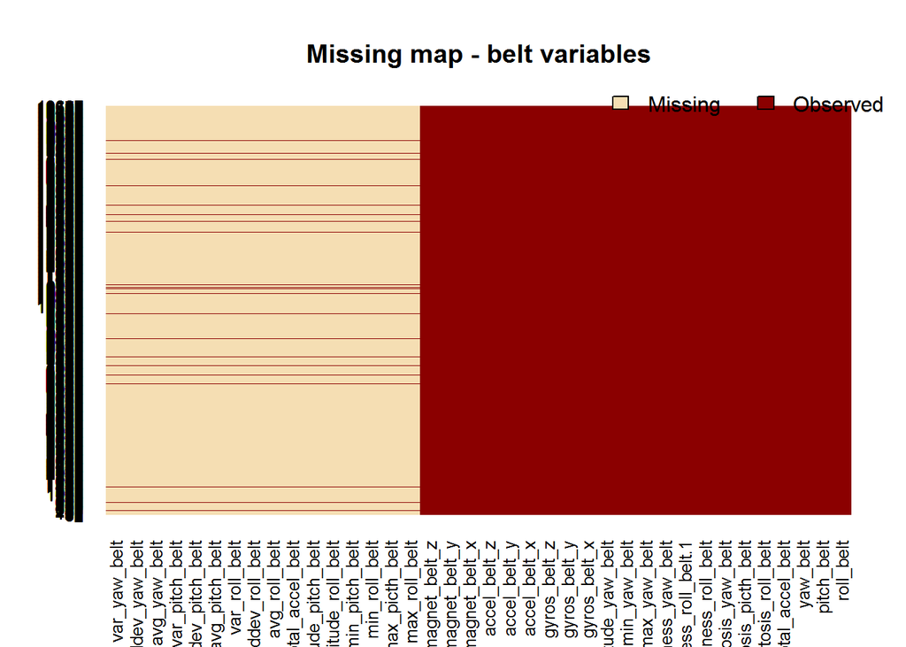

```r
missmap(train[grep("belt", names(train))], main="Missing map - belt variables")
```

In R, a missing value is often noted with the “NA” symbol, which stands for not available. Though you can assign an argument such as na.rm to remove the effect of NA, it is better to impute or remove the missing data in the dataset to prevent propagating the effect of the missing value.

Further examination reveled that the data contains:

- near zerovariables,
- “#DIV/0!” errors (division by zero)
- variables containing a high quantity of NAs.

Data needs to be sanitized where possible. Given that the amount of missing data is too large to attempt imputting via prediction packages, we eliminate them.

```r
# removing unnecessary features
train.clean <- train[,-c(1:6)]

# setting NAs to zero so that nzv (near zero covariates) will remove them
train.clean[is.na(train.clean)] <- 0

# obtains new dataframe without near zero covariantes
nzv <- nearZeroVar(train.clean)
train.nzv <- train.clean[,-nzv]
train.nzv$classe <- as.factor(train.nzv$classe)
dim(train.nzv)
```

```
## [1] 19622    54
```

The cleaned training set now presents only 54 meaningful variables. The outcome is then converted to a factor.

## Exploratory analysis

Outcomes of the exercises are classified as:

- Class A: correct exercise
- Class B,C,D,E: incorrect exercises corresponding to common mistakes

Given the high number of variables, it makes sense to perform an exploratory analysis. Let’s first review the outcomes

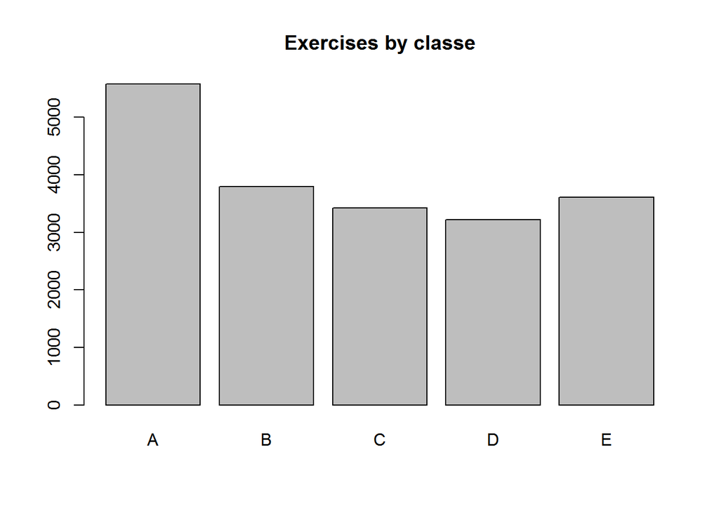

```r
barplot(table(train.nzv$classe), main="Exercises by classe")
```

# Feature Selection

Unlike other scenarios, where we can scan for features correlation in order to isolate the best features to be used in the prediction, in this study continuous variables do no really fit the approach. We therefore need to use a different approach to isolate those features that best fit our model.

First, we want to identify highly correlated attributes. Selecting the right features in the data can mean the difference between mediocre performance with long training times and great performance with short training times.

Let’s first analyse which are the most highly correlated variables.

```r
library(mlbench)
correlationMatrix <- cor(train.nzv[,1:ncol(train.nzv)-1])
highlyCorrelated <- findCorrelation(correlationMatrix, cutoff=0.75)
# removing highly correlated features
train.fin <- train.nzv[,-highlyCorrelated]
names(train.nzv)[highlyCorrelated]
```

```
##  [1] "accel_belt_z"      "roll_belt"         "accel_belt_y"
##  [4] "accel_arm_y"       "total_accel_belt"  "accel_dumbbell_z"
##  [7] "accel_belt_x"      "pitch_belt"        "magnet_dumbbell_x"
## [10] "accel_dumbbell_y"  "magnet_dumbbell_y" "accel_arm_x"
## [13] "accel_dumbbell_x"  "accel_arm_z"       "magnet_arm_y"
## [16] "magnet_belt_z"     "accel_forearm_y"   "gyros_dumbbell_x"
## [19] "gyros_forearm_y"   "gyros_dumbbell_z"  "gyros_arm_x"
```

Caret offers a popular automatic feature selection called Recursive Feature Elimination (RFE).

We will use a Random Forest algorithm to explore all possible subset of attributes. Given that the train sample is quite large (19622 rows), we will use a smaller sample of 500 rows to economize machine time

```r
# define the control using a random forest selection function
control <- rfeControl(functions=rfFuncs, method="cv", number=10, allowParallel = TRUE)
train.small <- train.fin[sample(nrow(train.fin), size=500),]
# run the RFE algorithm
results <- rfe(train.small[,1:ncol(train.small)-1], train.small[,ncol(train.small)], sizes=c(1:ncol(train.small)-1), rfeControl=control)
# list the chosen features
predictors(results)
```

```
## [1] "magnet_dumbbell_z" "magnet_belt_y"     "num_window"
## [4] "pitch_forearm"     "roll_forearm"      "yaw_belt"
```

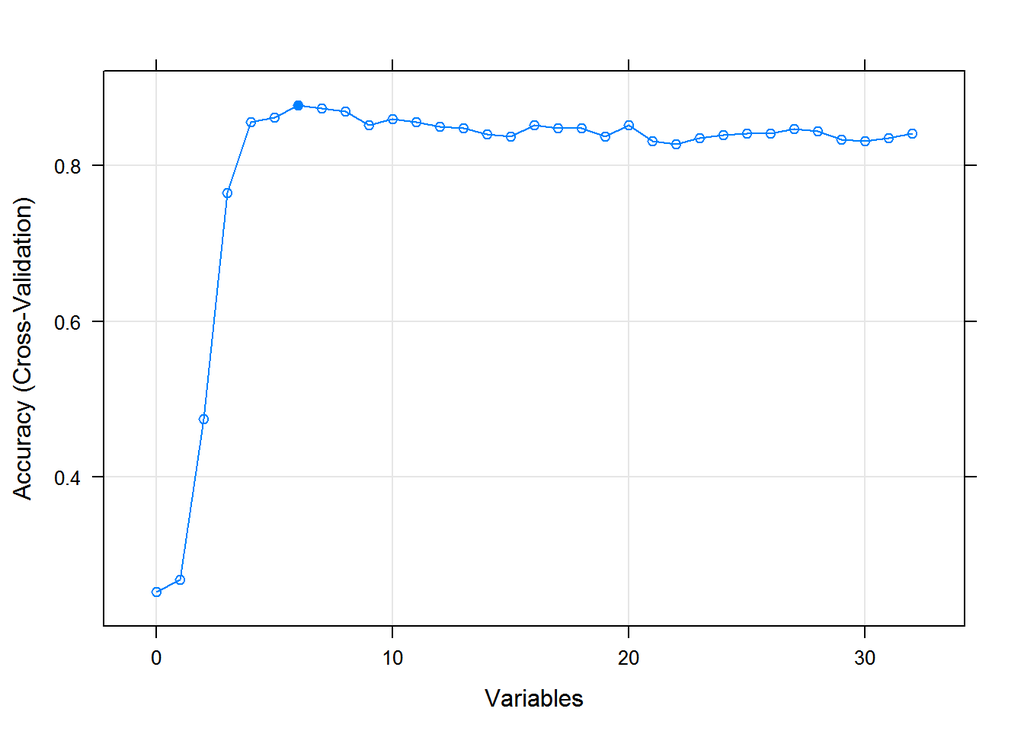

```r
# plot the results
plot(results, type=c("g", "o"))
```

```r
# and we get the final train dataset
train.fin <- train.fin[, c(predictors(results), "classe")]
```

## Cross Validation

The test sample will be used as a validation, therefore we will cross validate the training set. Training will provide the sub-training and the sub-testing.

```r
inTrain <- createDataPartition(y=train.fin$classe, p=0.7, list=FALSE)
subTrain <- train.nzv[inTrain,]
subTest <- train.nzv[-inTrain, ]
```

## Fitting the models

We will use four different classifiers and compare their result to select the best performing model.

The classifiers are:

- rpart
- lda
- knn
- rf

**WARNING this is going to take quite a while on the whole training sample**

After execution, the four models are compared to verify which one is the best performing.

```r
# prepare training scheme
control <- trainControl(method="cv", number=5, allowParallel = TRUE)
# CART
set.seed(12345)
fit.cart <- train(classe~., data=subTrain, method="rpart", trControl=control)
# LDA
set.seed(12345)
fit.lda <- train(classe~., data=subTrain, method="lda", trControl=control)
# kNN
set.seed(12345)
fit.knn <- train(classe~., data=subTrain, method="knn", trControl=control)
# Random Forest
set.seed(12345)
fit.rf <- train(classe~., data=subTrain, method="rf", trControl=control)
# collect resamples
results <- resamples(list(CART=fit.cart, LDA=fit.lda, KNN=fit.knn, RF=fit.rf))

# summarize differences between modes
summary(results)
```

```
##
## Call:
## summary.resamples(object = results)
##
## Models: CART, LDA, KNN, RF
## Number of resamples: 5
##
## Accuracy
##           Min.   1st Qu.    Median      Mean   3rd Qu.      Max. NA's
## CART 0.5898836 0.5924982 0.5926465 0.5986738 0.5942504 0.6240902    0
## LDA  0.6994178 0.7056041 0.7110626 0.7113650 0.7137655 0.7269749    0
## KNN  0.8932993 0.8941048 0.8951965 0.8973570 0.8984347 0.9057496    0
## RF   0.9930859 0.9952658 0.9970888 0.9964329 0.9978158 0.9989083    0
##
## Kappa
##           Min.   1st Qu.    Median      Mean   3rd Qu.      Max. NA's
## CART 0.4806152 0.4820924 0.4858564 0.4907838 0.4863185 0.5190364    0
## LDA  0.6193999 0.6271158 0.6346275 0.6347355 0.6383180 0.6542163    0
## KNN  0.8650669 0.8660563 0.8673632 0.8701421 0.8713851 0.8808392    0
## RF   0.9912543 0.9940119 0.9963177 0.9954881 0.9972372 0.9986193    0
```

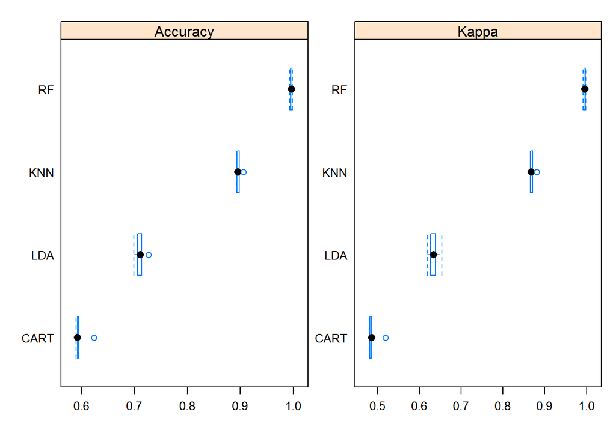

```r
# box and whisker plots to compare models
scales <- list(x=list(relation="free"), y=list(relation="free"))
bwplot(results, scales=scales)
```

Comparing the results of four regression models, it appears clear that Random Forests largely outperform every other algorithm.

## Out-of-Sample Errors

Let’s now use the Random Forest model to predict on the sub-test set to calculate the out-of-sample errors.

```r
predSubTest <- predict(fit.rf, newdata=subTest)
confm <- confusionMatrix(predSubTest, subTest$classe)
```

```r
print(confm$table)
```

```
##           Reference
## Prediction    A    B    C    D    E
##          A 1674    2    0    0    0
##          B    0 1137    1    0    0
##          C    0    0 1025    6    0
##          D    0    0    0  958    2
##          E    0    0    0    0 1080
```

```r
print(confm$overall[1])
```

```
##  Accuracy
## 0.9981308
```

Let’s verify the out-of-sample Error rate manually.

```r
samAcc <- sum(predSubTest == subTest$classe)/length(predSubTest)
oosErr <- (1 - samAcc) * 100
print(oosErr)
```

```
## [1] 0.1869159
```

## Applying the model to the test set

We now have our final model that we can apply to the real test set, and we finally can submit to the Course Project Prediction Quiz.

In order to respect the Coursera Honour Code, the final steps are obfuscated. There’s no free lunch…